# Projects in Data Science Activity A2c: Univariate and Bivariate Visualization

Hoang Anh Thai Vu

# Univariate Visualizations

**Example 1** The “Bechdel test”, named after cartoonist Alison Bechdel, tests whether movies meet the following criteria:

- there are $\ge$ 2 (named) female characters;
- these women talk to each other…
- about something other than a man

In the fivethirtyeight.com article [“The Dollar-And-Cents Case Against Hollywood’s Exclusion of Women,”](http://fivethirtyeight.com/features/the-dollar-and-cents-case-against-hollywoods-exclusion-of-women/) the authors analyze which Hollywood movies do/don’t pass the test. Their data are available in the `fivethirtyeight` package:

```r
library(fivethirtyeight)
data(bechdel)
DT::datatable(bechdel[,c(1,2,3,5,6,11:13)], options = list(pageLength = 10))
```

|  | year | imdb | title | clean_test | binary | budget_2013 | domgross_2013 | intgross_2013 |
| --- | --- | --- | --- | --- | --- | --- | --- | --- |
| 1 | 2013 | tt1711425 | 21 &amp; Over | notalk | FAIL | 13000000 | 25682380 | 42195766 |
| 2 | 2012 | tt1343727 | Dredd 3D | ok | PASS | 45658735 | 13611086 | 41467257 |
| 3 | 2013 | tt2024544 | 12 Years a Slave | notalk | FAIL | 20000000 | 53107035 | 158607035 |
| 4 | 2013 | tt1272878 | 2 Guns | notalk | FAIL | 61000000 | 75612460 | 132493015 |
| 5 | 2013 | tt0453562 | 42 | men | FAIL | 40000000 | 95020213 | 95020213 |
| 6 | 2013 | tt1335975 | 47 Ronin | men | FAIL | 225000000 | 38362475 | 145803842 |
| 7 | 2013 | tt1606378 | A Good Day to Die Hard | notalk | FAIL | 92000000 | 67349198 | 304249198 |
| 8 | 2013 | tt2194499 | About Time | ok | PASS | 12000000 | 15323921 | 87324746 |
| 9 | 2013 | tt1814621 | Admission | ok | PASS | 13000000 | 18007317 | 18007317 |
| 10 | 2013 | tt1815862 | After Earth | notalk | FAIL | 130000000 | 60522097 | 244373198 |

[output cut: 1784 more lines]

**Exercise 1** Before diving into any visualizations of these data, we first must understand its structure and contents.  
a. What are the units of observation and how many units are in this sample?

A data frame with 1794 rows representing movies and 15 variables

```
b. What are the levels of the `clean_test` and `binary` variables?
```

clean_test: bechdel test result (detailed): ok = passes test, dubious, men = women only talk about men, notalk = women don’t talk to each other, nowomen = fewer than two women

binary: Bechdel Test PASS vs FAIL binary

```
c. Check out the codebook for `bechdel`.  What's the difference between `domgross_2013` and `domgross`?
```

domgross: Domestic (US) gross

domgross_2013: Domestic gross (US) in 2013 inflation adjusted dollars

**Exercise 2** We’ll consider *univariate* visualizations of the `clean_test` and `budget_2013` variables.  
a. What features would we like a visualization of the *categorical* `clean_test` variable to capture?

We would like the visualization of clean_test variable to capture the distribution (discrete) of each category in clean_test.

```
b. What features would we like a visualization of the *quantitative* `budget_2013` variable to capture?
```

We would like the visualization of budget_2013 to capture the range, average and cluster/dispersion of values in budget_2013.

**Exercise 3 (Categorical Univariate Visualization)** Our first research questions are: Among the movies in our sample, what fraction pass the Bechdel test? Among those that fail the test, in which way do they fail (eg: there are no women, there are women but they only talk about men, etc)?

To answer these questions, use `geom_bar()` to examine the `clean_test` category. Make sure to label your axes and make choices about aesthetics such as fill colors. What do you learn from the graphic about the distribution of the `clean_test` variable?

> **Visualizing Categorical Variables**

> In examining plots of a categorical variable, take note of the following features:
> - **variability**  
>   Are cases evenly spread out among the categories or are some categories more common than others?
> - **contextual implications**  
>   In the context of your research, what do you learn from the bar chart? How would you describe your findings to a broad audience?

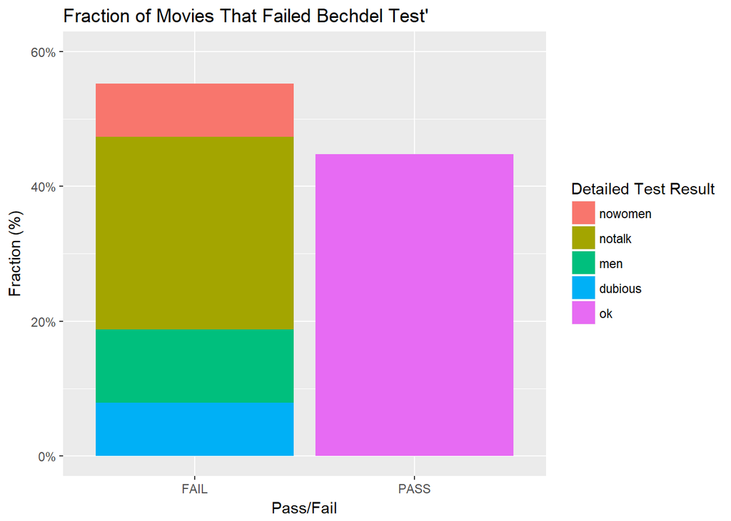

```r
UniTest <- bechdel%>%
  select(clean_test,binary)

ggplot(UniTest,aes(x=binary,y = (..count..)/sum(..count..)))+
  geom_bar(aes(fill=clean_test),position="stack")+
  ggtitle("Fraction of Movies That Failed Bechdel Test'")+
  labs(fill="Detailed Test Result")+
  xlab("Pass/Fail")+
  ylab("Fraction (%)")+
  scale_y_continuous(labels = scales::percent,limits = c(0,.6))
```

We could learn from the visualization that most movies failed the test. Among those that failed, only few failed because of there are fewer than two women. Most common reasons are women don’t talk to each other, and then women only talk about men.

**Exercise 4 (Quantitative Univariate Visualization)** Our next research questions are about movie budgets: Among the movies in our sample, what’s the range of budgets? What’s the typical budget? The largest/smallest?

We can answer these questions by exploring the *quantitative* `budget_2013` variable. Use different geometries in `ggplot` to create at least three different graphics to answer these questions, including at least one density plot and one histogram. Try to add vertical lines for the mean and median to your density plot. Make sure to label your axes and make choices about aesthetics such as fill colors. What the are the advantages/disadvantages of each geometry you chose? What do you learn from the graphics about the distribution of the `budget_2013` variable?

> **Visualizing Quantitative Variables**

> In examining plots of a quantitative variable, take note of the following features:
> - **center**  
>   Where’s the center of the distribution? What’s a typical value of the variable?
> - **variability**  
>   How spread out are the values? A lot or a little?
> - **shape**  
>   How are values distributed along the observed range? Is the distribution symmetric, right-skewed, left-skewed, bi-modal, or uniform (flat)?
> - **outliers**  
>   Are there any *outliers*, ie. values that are unusually large/small relative to the bulk of other values?
> - **contextual implications**  
>   Interpret these features in the context of your research. How would you describe your findings to a broad audience?

```r
scatter <- ggplot(bechdel)+
  geom_point(aes(x=budget_2013,y=budget_2013))+
  scale_x_continuous(name="Budget", labels = scales::comma)+
  scale_y_continuous(name="Budget", labels = scales::comma)+
  labs(title="Bechdel Movie Budget", subtitle="in 2013 inflation adjusted dollars")

dens <- ggplot(bechdel)+
  geom_density(aes(budget_2013))+
  scale_x_continuous(name="Budget", labels = scales::comma)+
  scale_y_continuous(name="density", labels = scales::comma)+
  labs(title="Bechdel Movie Budget", subtitle="in 2013 inflation adjusted dollars")

hist <- ggplot(bechdel)+
  geom_histogram(aes(budget_2013),bins=50)+
  scale_x_continuous(name="Budget", labels = scales::comma)+
  labs(title="Bechdel Movie Budget", subtitle="in 2013 inflation adjusted dollars")
```

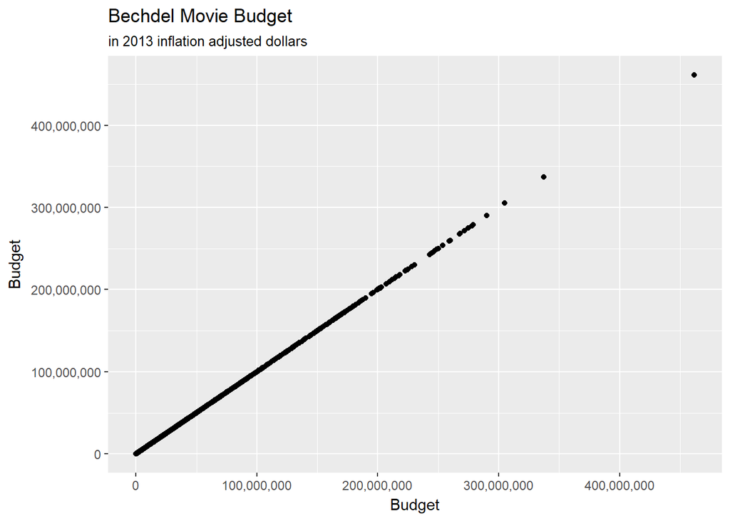

```r
scatter
```

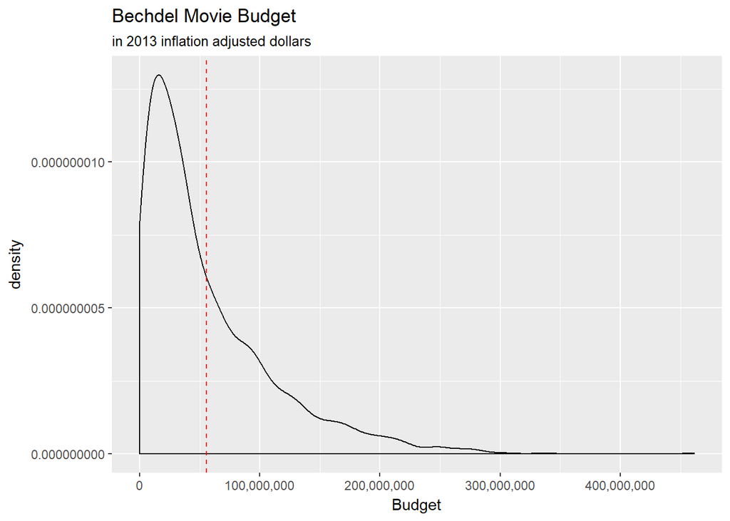

```r
dens+
  geom_vline(aes(xintercept=mean(bechdel$budget_2013)),linetype="dashed", size=0.5, color="red")
```

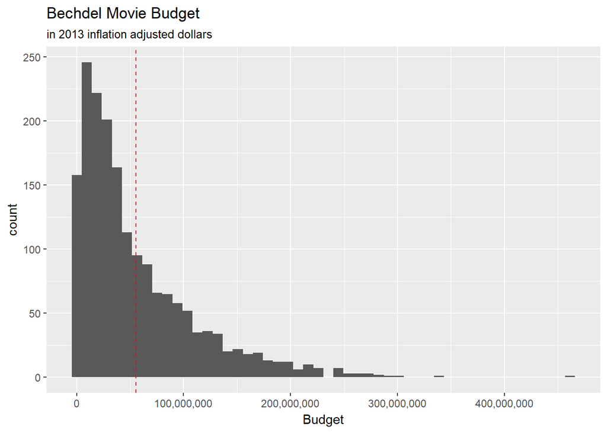

```r
hist+
  geom_vline(aes(xintercept=mean(bechdel$budget_2013)),linetype="dashed", size=0.5, color="red")
```

I used scatterplot, density and histogram to visualize the data. For scatter plot, we could see the points and how they cluster, but the distribution was not that clear. Density and histogram are more clear in illustrating the distribution. Density are smoother, but it is harder to interpret. The histogram only show the count for each range, which is not as detailed as the density.

# Bivariate Visualizations

**Response Variables vs Predictors**

Recall from MATH 155 the difference between response variables and predictors (explanatory variables):

- **response variable**: the variable whose variability we would like to explain
- **predictors**: variables that might explain some of the variability in the response

**Visualization Goals**

In exploring relationships between variables, we want to construct visualizations that allow us to examine/identify the following features:

- relationship *trends*
- relationship *strength* (degree of variability from the trend)
- *outliers* in the relationship

As with univariate plots, choosing appropriate visualizations of relationships depends upon whether the variables are quantitative or categorical.

## Quantitative vs. Quantitative

**Exercise 5** Let’s examine the relationship between the movie’s budget (`budget_2013`), the result of the Bechdel test (`clean_test`), and the international gross revenue (`intgross_2013`), the last of which will be the response variable.

1. In investigating budgets and profits, the authors “focus on films released from 1990 to 2013, since the data has significantly more depth since then.” Filter out the data to exclude any movies before 1990.
2. Use `geom_point()` to make a scatterplot with `budget_2013` on the x-axis and `intgross_2013` on the y-axis.
3. Add appropriate axis labels.
4. Explore relationship trends with `geom_smooth()`. Use both a linear model and the default localized linear (non-linear) model fit. You might also want to play with the transparency of the points in the scatterplot.
5. Are there outliers in the data? If so, identify them in a table.
6. Change the color of the points to show whether the movie passes the Bechdel test. Is it more effective to show all levels or use the `binary` variable to only show whether the movie passes?
7. Is it more effective to facet the scatterplot by the result of the Bechdel test?
8. Use `lm` to generate a linear regression model with `intgross_2013` as the response variable and `budget_2013` and `binary` as the explanatory variables. Interpret the coefficient on `binary`.

The following line removes cases that are missing the budget or international gross amounts:

```r
bechdelBudget<-bechdel[complete.cases(bechdel[ , c(11,13)]),]
```

```r
bechdel9013 <- bechdel %>%
  filter(year>=1990 & year<=2013)
```

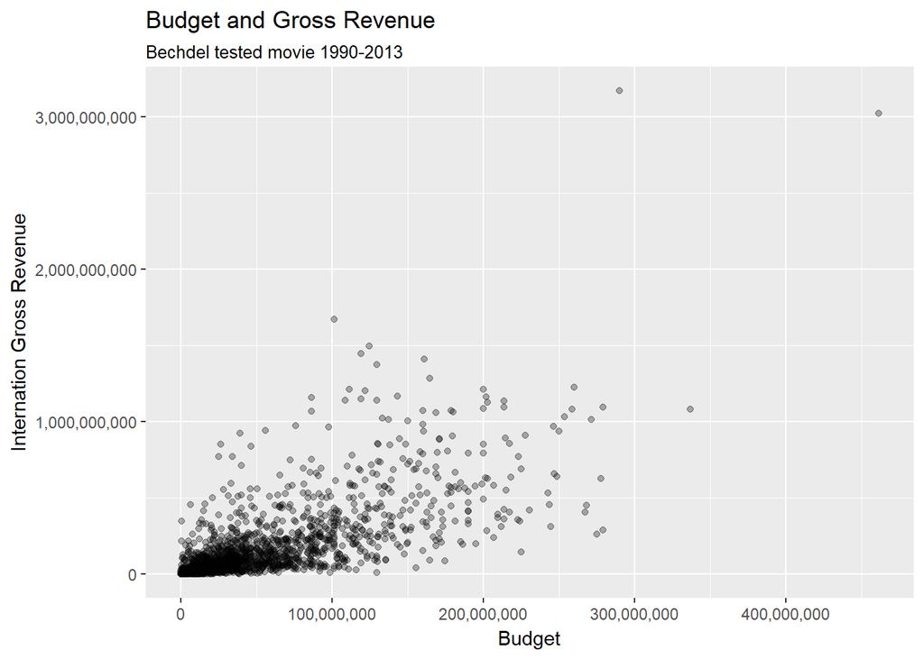

```r
b=ggplot(bechdel9013, aes(x=budget_2013,y=intgross_2013))+
  geom_point(alpha=0.3)+
  scale_x_continuous(name="Budget", labels = scales::comma)+
  scale_y_continuous(name="Internation Gross Revenue", labels = scales::comma)+
  labs(title="Budget and Gross Revenue", subtitle="Bechdel tested movie 1990-2013")
b
```

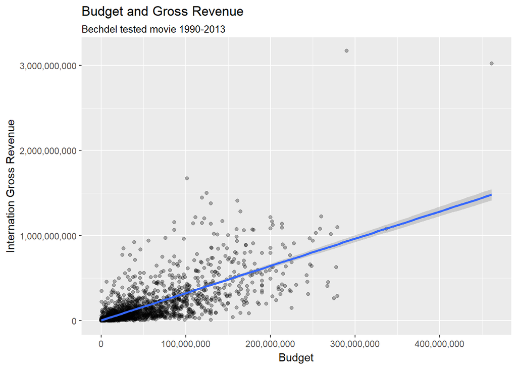

```r
d.linear=b+geom_smooth(method=lm)
d.default=b+geom_smooth()

d.linear
```

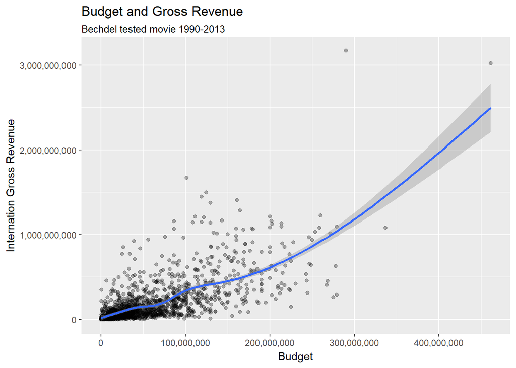

```r
d.default
```

5. Yes, there are outliers.

```r
bechdel.outlier <- bechdel9013%>%
  arrange(desc(intgross_2013))%>%
  head(n=2)
```

```r
knitr::kable(
  bechdel.outlier[,], caption = "Outliers"
)
```

Table 1: Outliers

| year | imdb | title | test | clean_test | binary | budget | domgross | intgross | code | budget_2013 | domgross_2013 | intgross_2013 | period_code | decade_code |
| --- | --- | --- | --- | --- | --- | --- | --- | --- | --- | --- | --- | --- | --- | --- |
| 1997 | tt0120338 | Titanic | ok | ok | PASS | 2.00e+08 | 658672302 | 2185672302 | 1997PASS | 290247625 | 955890356 | 3171930973 | 4 | 3 |
| 2009 | tt0499549 | Avatar | men-disagree | men | FAIL | 4.25e+08 | 760507625 | 2783918982 | 2009FAIL | 461435929 | 825707158 | 3022588801 | 2 | 2 |

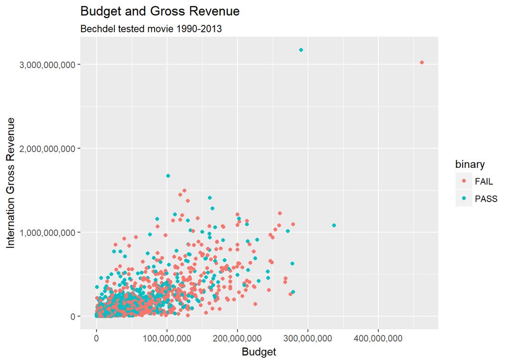

```r
b+geom_point(aes(color=binary))
```

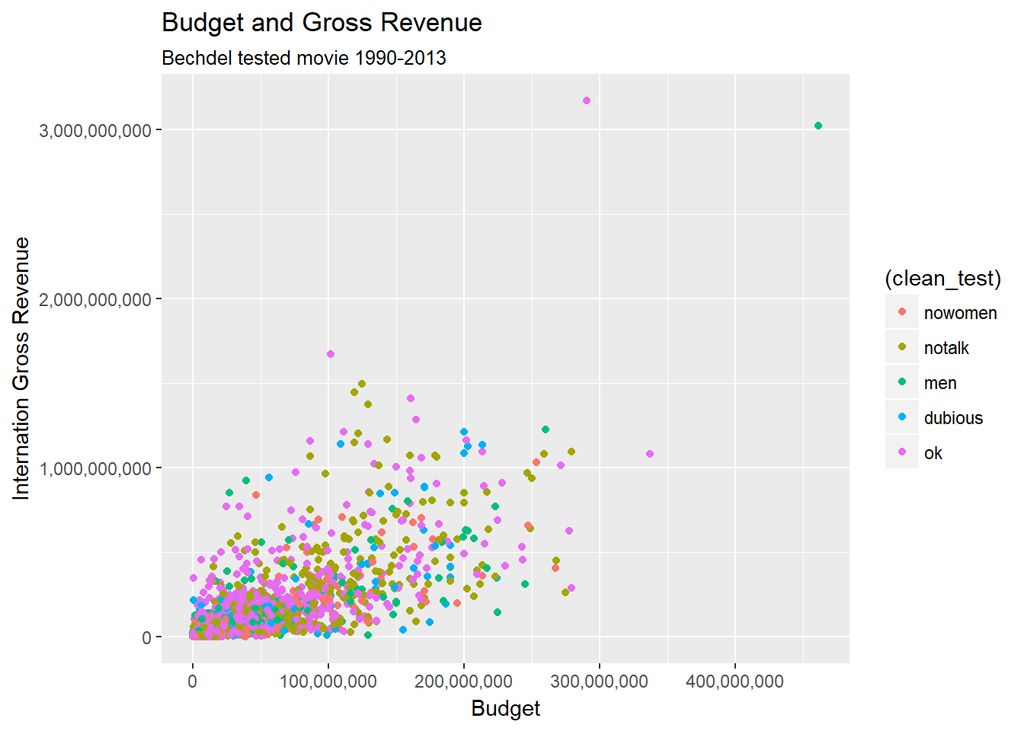

```r
b+geom_point(aes(color=(clean_test)))
```

It is not more effective showing all test results since there are too much information to comprehend.

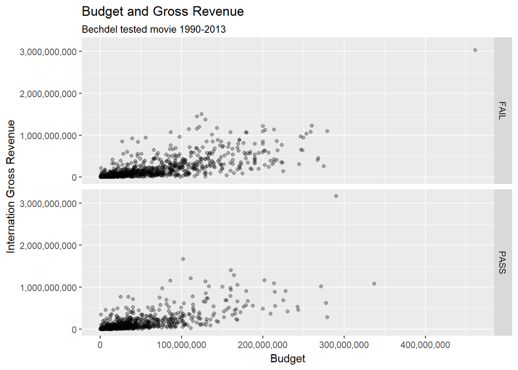

```r
b+facet_grid(binary~.)
```

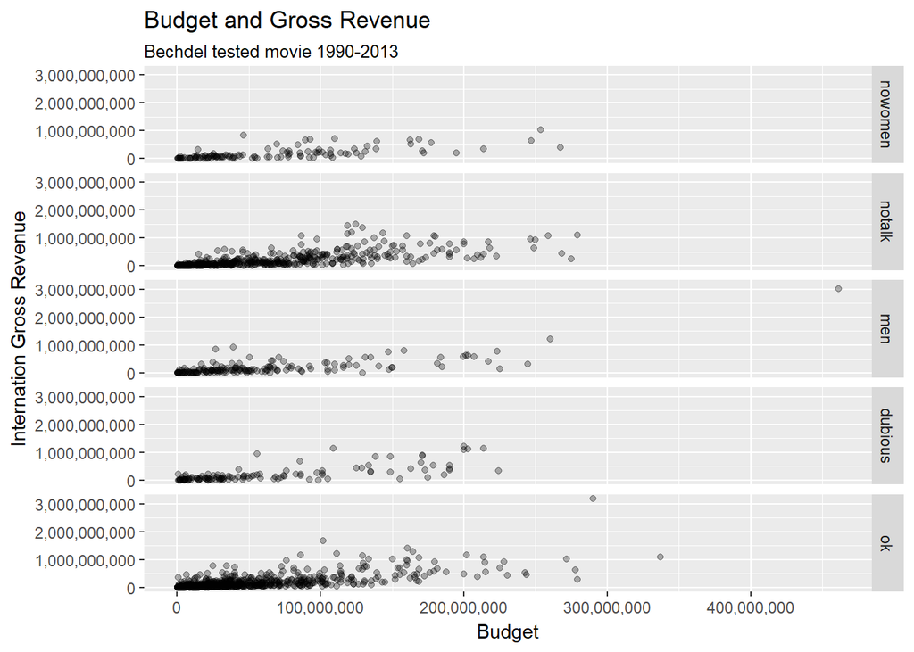

```r
b+facet_grid(clean_test~.)
```

It is much more effective! You could see the difference clearly.

## Quantitative vs. Categorical

**Exercise 6** The next research question is how the distribution of Bechdel test results has changed over time. To explore this trend, first create a new variable that groups the years into buckets with the following command:

This exercise is inspired by a similar exercise proposed by Albert Kim, one of the `fivethirtyeight` package authors.

```r
newbechdel <- bechdel %>%
  mutate(yearCat=cut(year, breaks=seq(1969,2014,by=5)))
```

Then use `geom_bar()` with `YearCat` as the x-variable and `clean_test` as the `fill`. Experiment with the `position` aesthetic of `geom_bar()` by making the same plot with four different positions: “dodge”, “identity”, “fill”, and “stack.” Take note of what the different arguments do to the histogram and make sure to label your axes accordingly. Evaluate which is the best `position` to use to answer this research question. For each of your ggplot calls, include the following lines:

Hint: There will be at least two different labels for the y-axis.

```r
p<-ggplot(newbechdel)+
  scale_fill_manual(values = c("red","salmon","pink","steelblue1","steelblue4")) +
  theme(axis.text.x=element_text(angle=45,hjust=1))
```

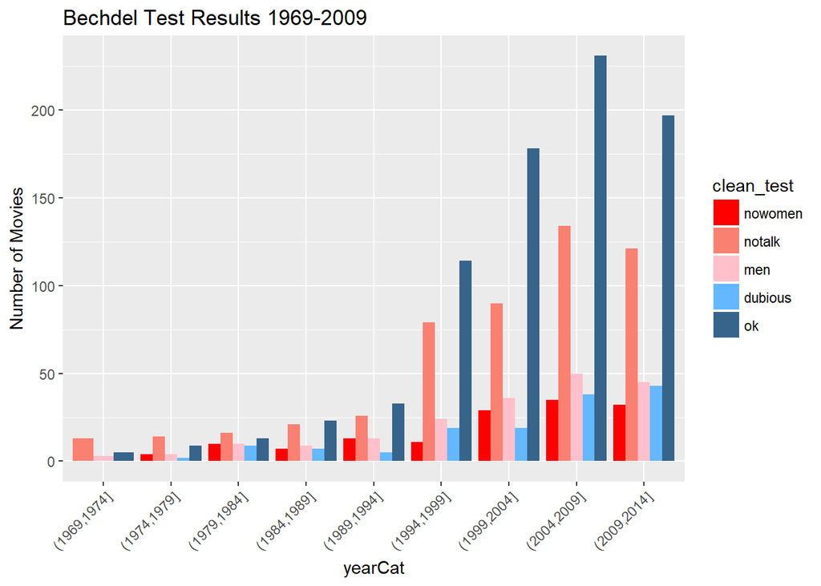

```r
p+geom_bar(aes(x=yearCat,fill=clean_test),position="dodge")+
  labs(y="Number of Movies",title="Bechdel Test Results 1969-2009")
```

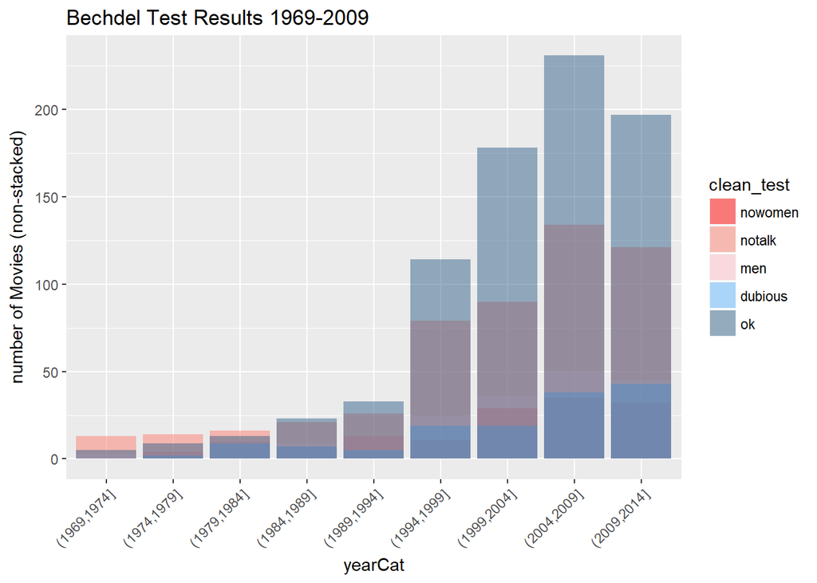

```r
p+geom_bar(aes(x=yearCat,fill=clean_test),position="identity",alpha=0.5)+
  labs(y="number of Movies (non-stacked)",title="Bechdel Test Results 1969-2009")
```

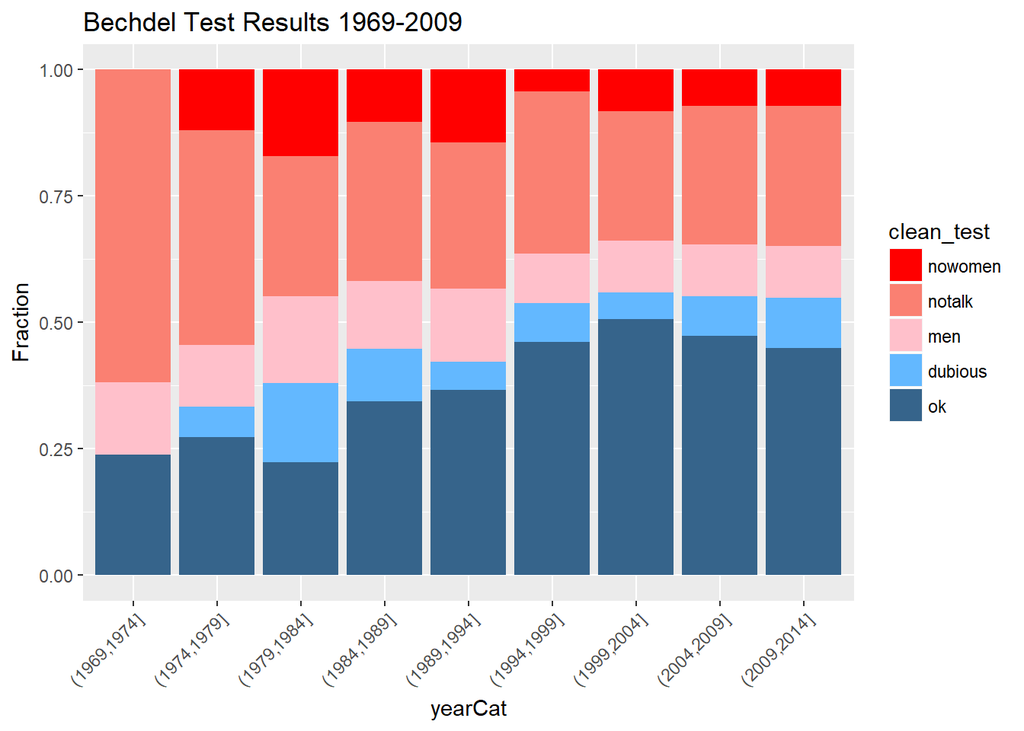

```r
p+geom_bar(aes(x=yearCat,fill=clean_test),position="fill")+
  labs(y="Fraction",title="Bechdel Test Results 1969-2009")
```

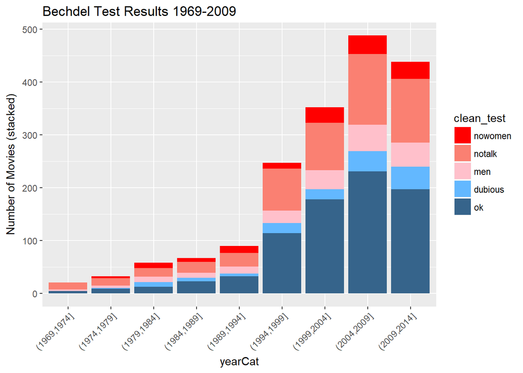

[figure not shown]

[figure not shown]

```r
p+geom_bar(aes(x=yearCat,fill=clean_test),position="stack")+
  labs(y="Number of Movies (stacked)",title="Bechdel Test Results 1969-2009")
```

**Exercise 7** The article says the data suggest that “Hollywood puts more money behind male-only films than films in which women talk to each other,” and the author brainstorms a number of reasons why this may be. Let’s investigate the hypothesis. Again, use only films made in 1990 or later. For all parts, use `fill=clean_test` and set the colors according to `scale_fill_manual(values = c("red","salmon","pink","steelblue1","steelblue4"))`.

1. Plot the densities of `budget_2013`, faceted by `clean_test`.
2. Plot the densities of `budget_2013` on the same chart, but colored differently according to `clean_test` (i.e., there should be one density plot for each level of `clean_test`). You may have to play with the `alpha` level.
3. Make side-by-side boxplots with each level having its own box, and the `budget_2013` on the y-axis.
4. Repeat part (c) with side-by-side violins instead of boxplots.
5. Which visualization do you find to be the most effective?

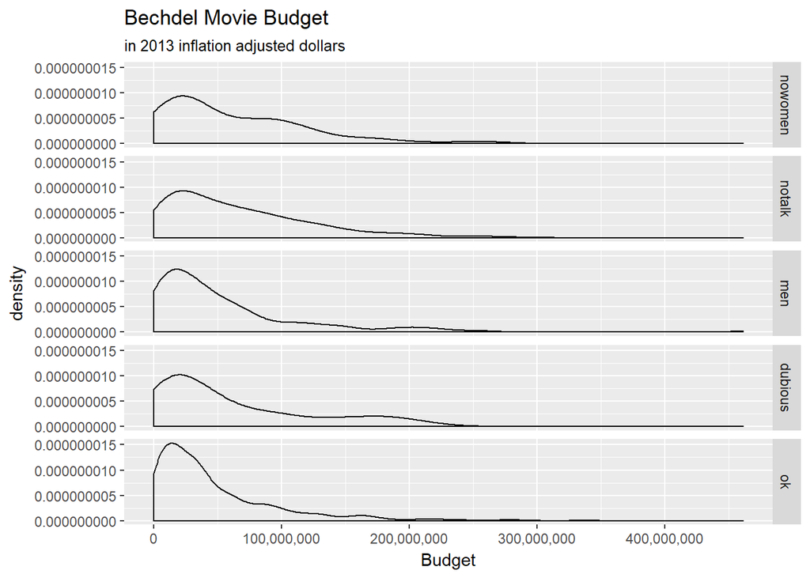

```r
dens+facet_grid(clean_test~.)
```

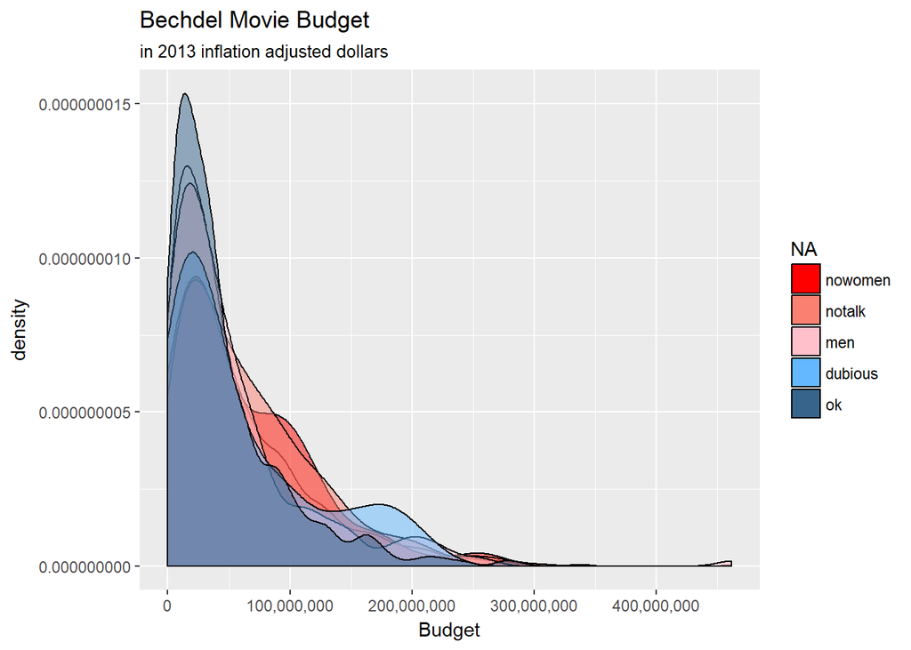

```r
dens+geom_density(aes(x=budget_2013,fill=clean_test),alpha=0.5)+
  scale_fill_manual(values = c("red","salmon","pink","steelblue1","steelblue4"))
```

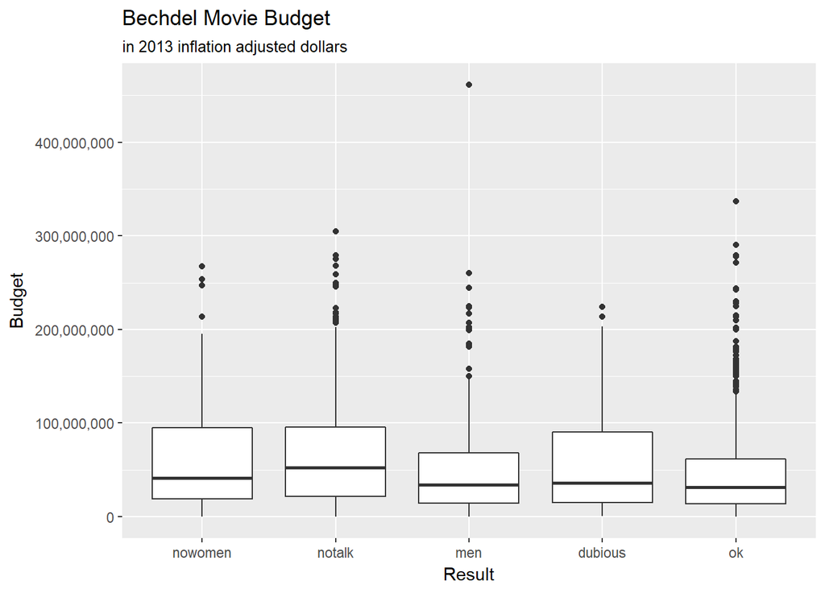

```r
ggplot(bechdel)+
  geom_boxplot(aes(clean_test,budget_2013))+
  scale_y_continuous(name="Budget", labels = scales::comma)+
  labs(x="Result",title="Bechdel Movie Budget", subtitle="in 2013 inflation adjusted dollars")
```

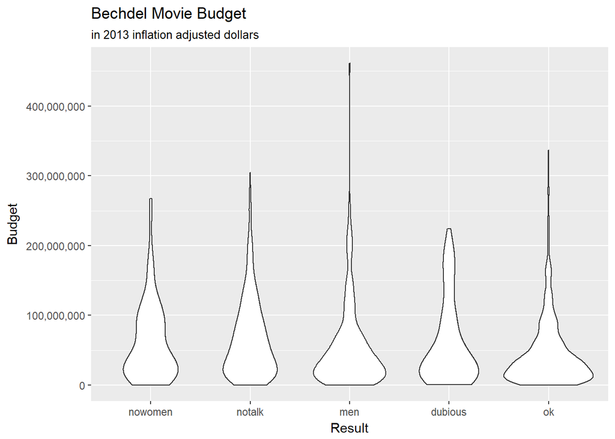

```r
ggplot(bechdel)+
  geom_violin(aes(clean_test,budget_2013))+
  scale_y_continuous(name="Budget", labels = scales::comma)+
  labs(x="Result",title="Bechdel Movie Budget", subtitle="in 2013 inflation adjusted dollars")
```

I found the violin most effective to observe the different in distribution accross different results.

## Categorical vs. Categorical

When looking at relationships between two categorical variables, the most common type of visualization is a histogram like those we made in Exercise 6. Another option is the `geom_count()` geometry.

**Exercise 8** Use `geom_count()` to examine the relationship between `period_code` on the x-axis and `clean_test` on the y-axis. Do you find this more or less effective than a histogram?

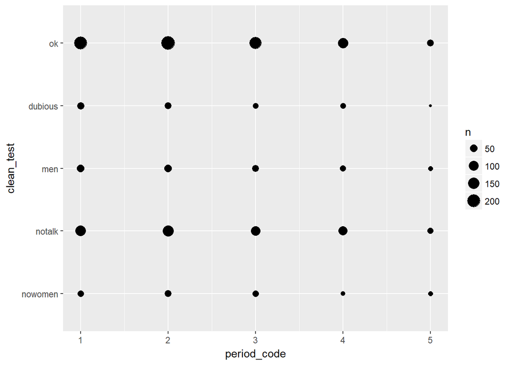

```r
ggplot(newbechdel)+
  geom_count(aes(x=period_code,y=clean_test))
```

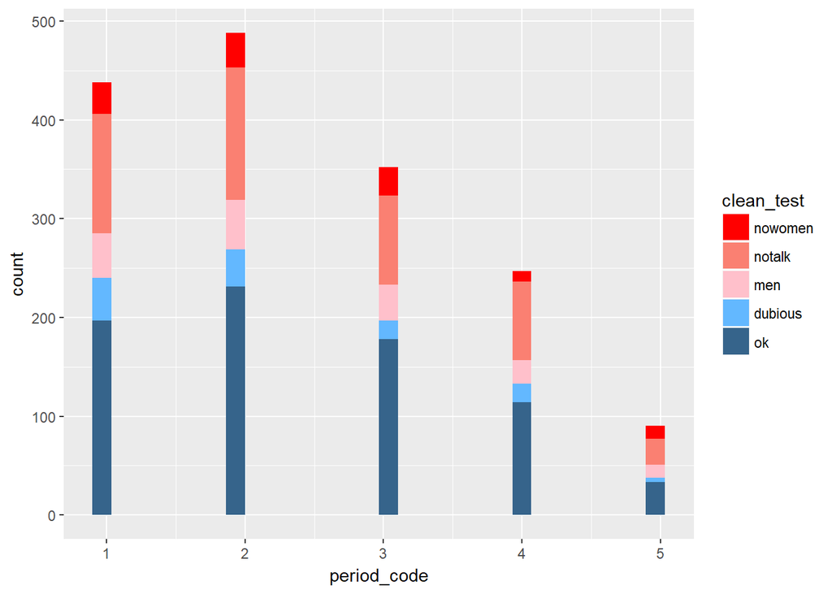

```r
ggplot(newbechdel)+
  geom_histogram(aes(period_code,fill=clean_test))+
  scale_fill_manual(values = c("red","salmon","pink","steelblue1","steelblue4"))
```

I found the geom_count more eye pleasing, but harder to do the comparision of points size in comparison to the histogram.